# Investigating Politics

January 5, 2018

## Motivating Puzzles

POLI 110

## Communal Violence in India

- Largest democracy, arguably most diverse
- But ethnic violence a problem since Independence (1947)
- Can democracy be compatible with such diversity?

## Ram Ke Naam

### "In the Name of God"

- 1991 Documentary
- Covers protest and political activity around Babri Masjid (mosque) in Ayodhya

### While you watch

- What questions this film raises for you?
- particularly about politics
- Write those questions down

[video not shown]

## What questions did this raise?

## Some kinds of question:

### Specific

- What caused the conflict over the Babri Masjid?
  - deep historical religious tensions?
  - modern politics?
- Did the Rath Yatra (BJP/Advani's pilgrimage to Ayodhya):
  - have political benefits for the BJP?
  - lead to violence?
- Do caste differences intensify or weaken Hindu-Muslim tensions?

## Some kinds of question:

### General

- Does democracy intensify or moderate ethnic/religious differences?
- How can minority groups receive protections in a democracy?
- Do political parties stir up ethnic/religious conflicts?
- Do political parties make electoral gains from conflict?
- What kinds of constitutional arrangements make ethnic/religious conflict more or less likely?

## Two investigations

## Rath Yatra

### What effects did it have on

- voting?
- violence?

### Why might it have an effect?

Cultural appeals:

- drew upon Hindu religious iconography / pilgrimage
- aimed to unify religious community
- narrative in which Hindus victims of Muslims

Propaganda:

- major news coverage
- large audience: march moved through cities, towns, villages

## How would we know?

- How did the BJP performed in places along the route?
- Was there violence in places along the route?
- Ask people on the route?

### Compared to what?

- Occurrence of Yatra due to prior religious tensions
  - Any violence/ support for BJP incidental
- Yatra route chosen to visit supporters
  - BJP performance is better due to planning process, not event

## A social scientific approach:

Blakeslee (2014) looks at effect of location on Yatra Route on:

- 1991 MP elections
- Hindu-Muslim riots

## How

- Data on MP constituencies
  - did Yatra pass through
  - Election outcomes
  - attributes of places on Yatra route

## Do you see a pattern?

- Riots in red
- Yatra route in blue
- States: bold
- MP constituencies: thin

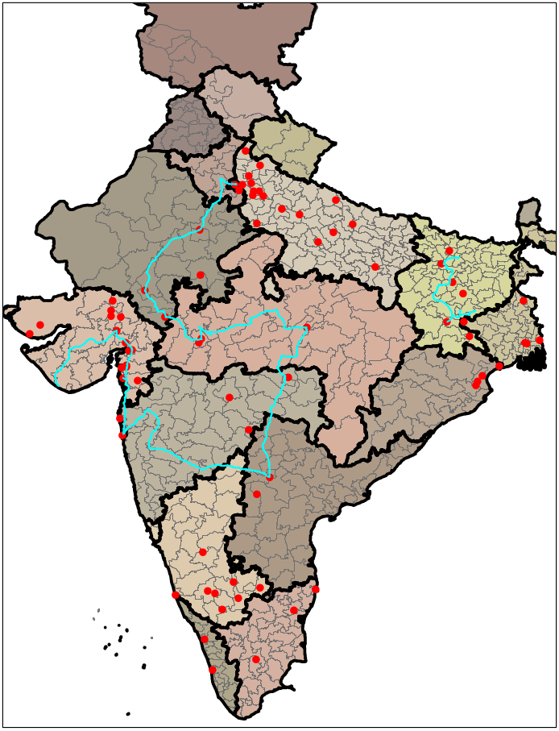

## Results: Riots

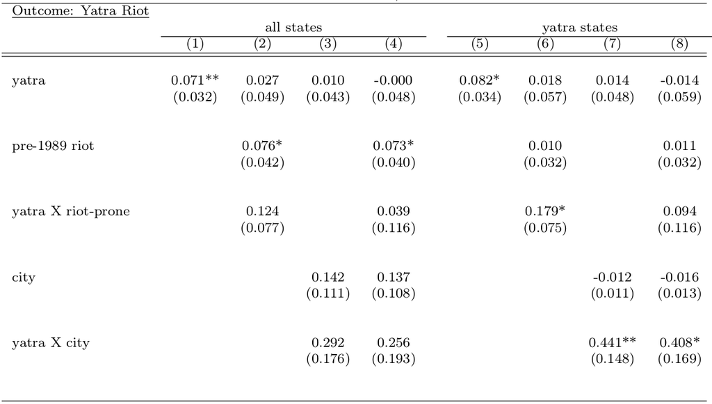

## Results: Riots

Finds more riots in places on the route…

## Do you see a pattern?

y: 1991 BJP % **|** x: 1989 BJP % **|** lines: average yatra/non-yatra

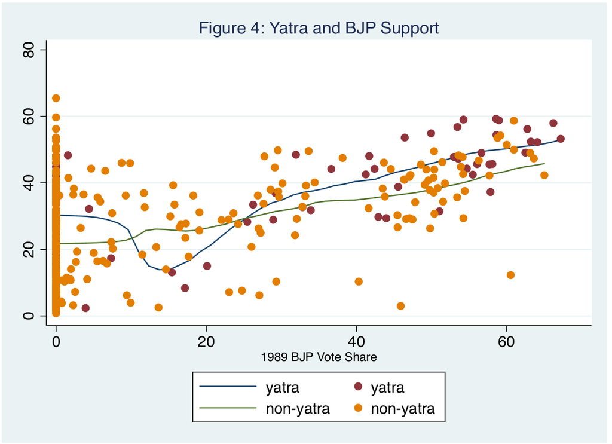

## Results: Elections

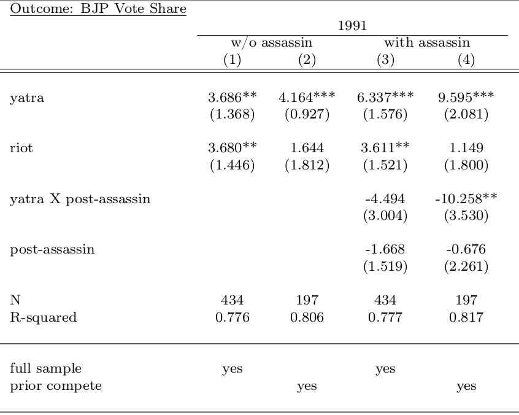

## Results: Elections

Finds more BJP votes in 1991 MP elections in places on route…

…even when comparing MP constituencies

- with similar histories of violence
- similar proximity to Ayodhya (end of Yatra)
- similar BJP electoral performance in 1989
- within the same state

## Healthy skepticism…

### Couldn't the route have been chosen to visit supporters?

If so, what pattern would you expect to see between:

- location on Yatra route
- pre-Yatra BJP electoral performance?

## What we *don't* observe is important:

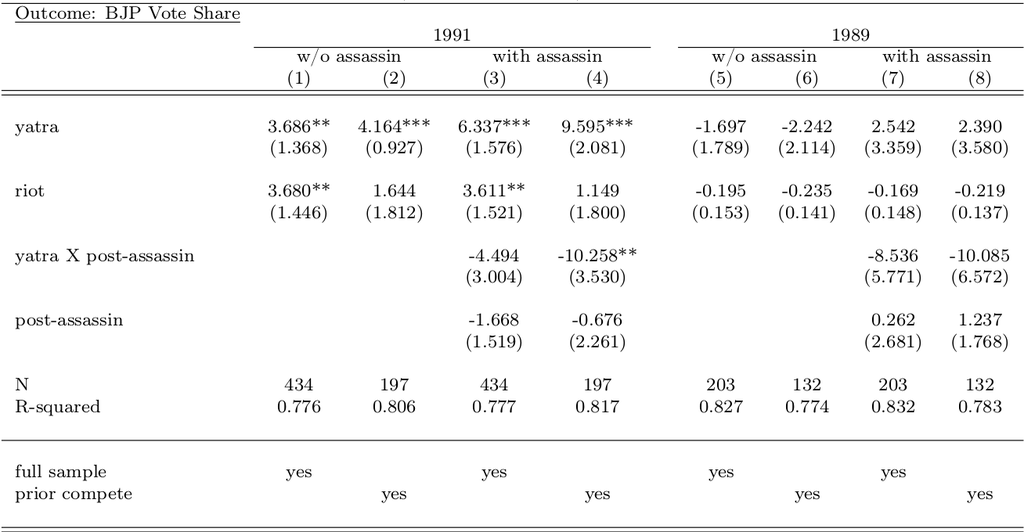

## What have we learned?

When political parties mobilize one religious group and play up religious differences:

- they can win voters from their religious group
- this religious mobilization can lead to violence

## How have we learned it?

### Not through:

- pundits/journalists/politicians
- documentary narratives
- common sense

### Using social science

## Another take:

### Do *secular* political parties *stop* religious violence?

### Maybe:

- Might back minority rights to ensure religious equality
- Religious violence might make religious parties more attractive
- More committed to law and order?

### Maybe not:

- may be hard for politicians to stop violence
- stopping violence may be seen as "taking sides", alienating voters
- *all* political parties motivated to maintain law and order

## A social scientific approach:

Looking at MLAs in India between 1961 and 2000

- Does having a "secular" MLA reduce religious violence?
  - Does having MLA from Indian National Congress (party of Gandhi, Nehru) reduce violence?
  - INC portrayed itself, seen as protector of minorities

## The study

What can we compare?

- Districts in which Congress MLA barely won, versus barely lost

Why?

- Should be quite similar
- Otherwise, e.g., places that vote more secular might have less religious animosity => less violence

## Close elections (less than 1%)

### Like a coin flip

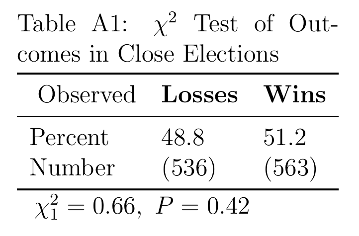

## Close elections (less than 1%)

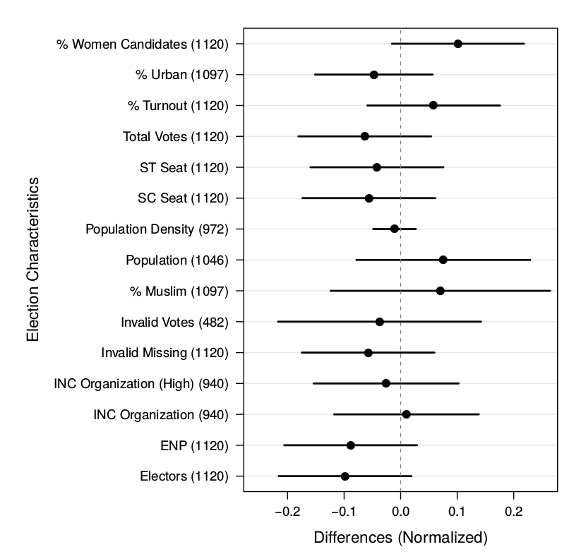

## Results

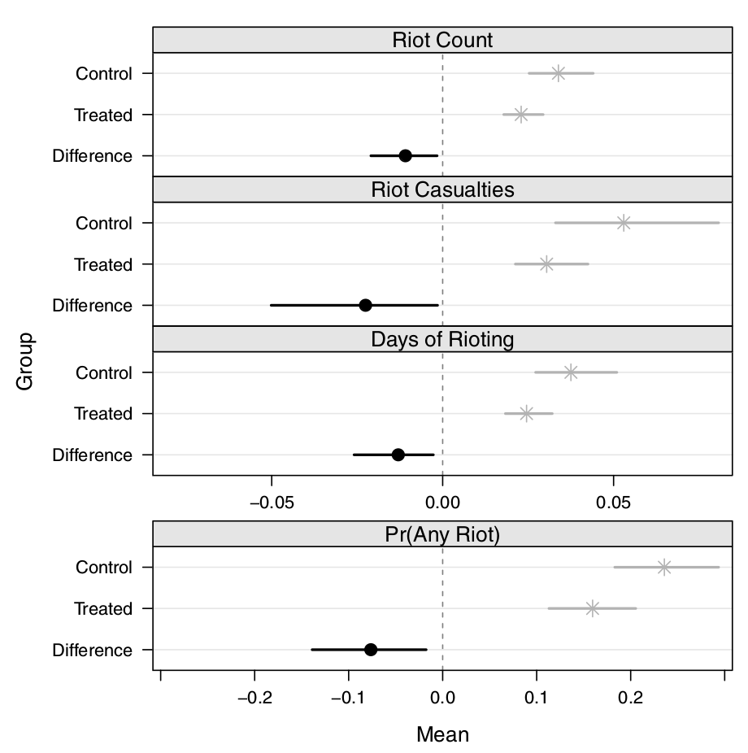

## Results:

Places where Congress MLA barely wins:

- Fewer riots, less likely to have **any** riots
- Less intense riots

### Why?

- Is it just **not** being a religious party?

## Something unique…

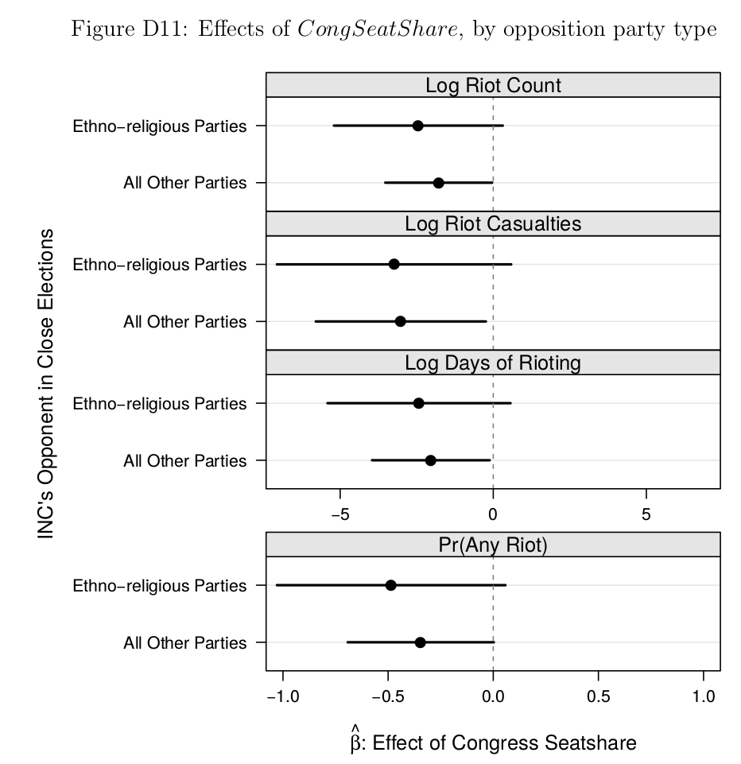

## Why?

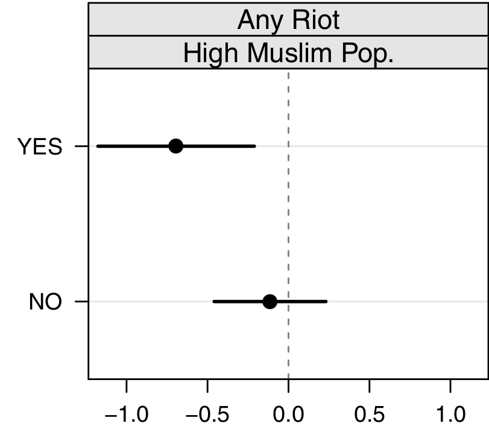

## Why?

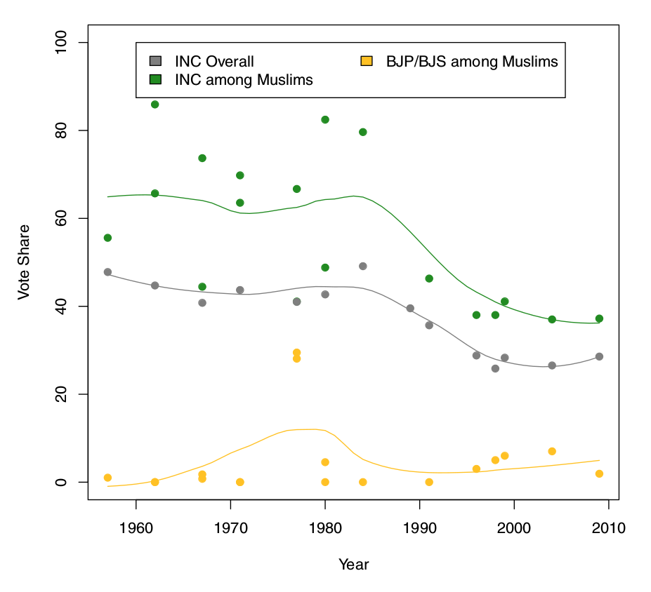

## What have we learned?

- Secular party lives up to commitments to protect minorities
- But, it appears to only do this when it is electorally beneficial